# Trabajo correlación final

Authors

Bernardita Ormeño

Santiago Romero

Juan Gutiérrez García

Orlando Morales

Sebastian Saldaña

# **Determinantes sociodemograficos del tiempo dedicado al trabajo no remunerado: Sexo, edad, ingreso y nivel educacional**

**Introducción** El presente trabajo aborda el trabajo no remunerado y sus determinantes sociodemográficos, lo que permitirá comprender quién lo realiza, bajo qué condiciones y con qué implicaciones. Esto revela una dimensión oculta pero estructural del funcionamiento económico actual. Entendemos el trabajo no remunerado como el conjunto de labores realizadas en los ámbitos doméstico y comunitario, tal como explica la Fundación SOL (Barriga et al., 2020), este tipo de trabajo incluye actividades como cocinar, limpiar, cuidar a personas dependientes y realizar tareas voluntarias. Aunque resultan esenciales para sostener la vida cotidiana y posibilitar el trabajo remunerado, son labores históricamente naturalizadas como responsabilidades femeninas y se realizan sin reconocimiento social ni compensación económica. En consecuencia, configuran una “red invisible de cuidados” que atraviesa tanto el espacio privado como el público. La relevancia del estudio del TNR radica en que constituye la base que posibilita la reproducción cotidiana de la fuerza laboral y, con ello, del propio sistema económico. Sin embargo, su exclusión de los sistemas de contabilidad nacional ha contribuido a invisibilizar su aporte y a reforzar jerarquías que consideran “no económico” aquello que sostiene la vida (Waring, 1990). Esta omisión no solo distorsiona indicadores como el PIB, sino que dificulta comprender cómo las desigualdades sociales estructuran la distribución del tiempo dedicado a estas tareas. A pesar de su importancia, el trabajo no remunerado continúa distribuyéndose de manera profundamente desigual, concentrándose principalmente en mujeres y en grupos con menor acceso a recursos. Esta desigualdad en la carga de cuidados se relaciona tanto con factores culturales como con condiciones económicas y estructurales que limitan la capacidad de ciertos grupos para externalizar o redistribuir estas tareas. Sin embargo, aún falta comprender con mayor precisión cómo diversos factores sociodemográficos inciden en el tiempo dedicado al trabajo no remunerado, especialmente en contextos donde las brechas de género y clase siguen siendo persistentes. Por ello, surge el problema de investigación: ¿qué características sociodemográficas explican las diferencias en el tiempo destinado al trabajo no remunerado y de qué manera estas desigualdades se relacionan entre sí? Comprender este patrón es clave para dimensionar las bases de la desigualdad de género y la distribución social del cuidado.

**Conceptos Clave**

Los conceptos claves a trabajar serán el trabajo no remunerado, el sexo, la edad, el ingreso y el nivel educacional, con el fin de comprender cómo estos factores estructuran la distribución del trabajo doméstico y de cuidado. El trabajo no remunerado se entiende como el conjunto de actividades domésticas y de cuidado realizadas sin pago, fundamentales para la reproducción de la vida (Vega, 2007). Su feminización histórica hace que el sexo sea una variable central: organismos internacionales como la OECD (2025) han mostrado consistentemente que las mujeres dedican muchas más horas que los hombres al trabajo doméstico, e incluso millones de ellas quedan fuera del mercado laboral por responsabilidades de cuidado no remunerado. La edad influye porque el peso del cuidado cambia a lo largo del ciclo vital, aumentando en etapas de crianza o cuidado de dependientes, tal como lo evidencia la CEPAL (s.f.) en sus análisis sobre uso del tiempo. Por su parte, el ingreso determina la capacidad de externalizar tareas domésticas mediante servicios pagados, lo que genera desigualdades en quién asume efectivamente el trabajo no remunerado. Finalmente, el nivel educacional se relaciona tanto con las oportunidades laborales como con normas culturales de organización del hogar, influyendo en cómo se negocia o distribuye el trabajo doméstico.

**objetivo general e hipótesis**

Esta investigación tiene como objetivo general analizar los factores que inciden en la participación laboral y en la distribución del tiempo dentro de los hogares.

1. Se plantea la hipótesis de que las horas de trabajo no remunerado están asociadas al sexo, considerando que estas tareas continúan recayendo mayoritariamente en las mujeres.
2. Se plantea la hipótesis de que las horas de trabajo no remunerado están vinculadas al nivel educacional, de modo que diferencias en educación pueden influir en la distribución y carga de las tareas domésticas.
3. Se plantea la hipótesis de que las horas de trabajo no remunerado están relacionadas con el quintil de ingresos, dado que los recursos económicos condicionan la posibilidad de externalizar labores domésticas.
4. Se plantea que las horas de trabajo no remunerado se relacionan con la edad, de manera que las personas en edades con mayores responsabilidades de cuidado —como la crianza de hijos o el cuidado de personas dependientes— dedican más tiempo a estas labores.
5. Se plantea la hipótesis de que el sexo está relacionado con el quintil de ingresos, dado que las mujeres realizan más trabajo no remunerado y esto podría limitar su presencia en los niveles de ingreso más altos.

**metodología**

Para el presente análisis se utilizaron datos provenientes de la Encuesta de Bienestar Social (EBS) 2023. La base de datos original fue sometida a un proceso de depuración y limpieza, gestionando casos perdidos y valores no válidos. Específicamente, se aplicó un criterio de eliminación por lits (listwise) para excluir observaciones con códigos de no respuesta( cómo -77, -88, -99) o en variables de interés. La muestra final que utilizamos quedó conformada por N = 10,104 casos válidos, garantizando consistencia para los análisis descriptivos e inferenciales. Todo el procesamiento de datos se realizó utilizando el software estadístico Rstudio.

```r
pacman::p_load(tidyverse, # Manipulacion datos
               sjPlot, # Graficos y tablas
               sjmisc, # Descriptivos
               corrplot, # Correlaciones
               psych,
               dyplr, # Test estadísticos
               kableExtra,
               haven,
               broom,
               haven,
               forcats,
               ggpubr,
               gginference,
               rempsyc,
               flextable,
               ggplot2)
Base_de_datos_EBS_2023 <- read_sav("C:/Users/sebag/OneDrive/Escritorio/Trabajo Correlación FINAL/Base de datos EBS 2023.SAV")

options(scipen = 999)
base_de_datos <- Base_de_datos_EBS_2023

names(Base_de_datos_EBS_2023)
```

```
  [1] "folio_et_enmascarado"      "id_unico_viv_enmascarado"
  [3] "id_hogar"                  "id_persona"
  [5] "glosa_region"              "glosa_area"
  [7] "cdf_unificado"             "hora_hr"
  [9] "fexp"                      "estrato_ebs"
 [11] "varunit"                   "l1"
 [13] "tramoebs2"                 "l1_a"
 [15] "sg01"                      "sg02"
 [17] "sg03"                      "l3_recat"
 [19] "l4"                        "l5_recat"
 [21] "l6"                        "l7"
 [23] "l8"                        "l9"
 [25] "l10"                       "l10_a"
 [27] "l11"                       "a1"
 [29] "a2_a"                      "a2_b"
```

[output cut: 123 more lines]

```r
#recodificar variables

Base_recodificada <- Base_de_datos_EBS_2023 %>% select(
  tnr,
  sg01,
  tramoebs2,
  qaut_casen,
  educ_recat_casen
  )

Base_recodificada %>% mutate(
  across(everything(), ~ na_if(., -99)),
  across(everything(), ~ na_if(., -88)),
  across(everything(), ~ na_if(., -89)),
 )
```

```
# A tibble: 11,234 × 5
     tnr sg01          tramoebs2           qaut_casen educ_recat_casen
   <dbl> <dbl+lbl>     <dbl+lbl>           <dbl+lbl>  <dbl+lbl>
 1    30 2 [2. Mujer]  3 [3. 45 a 59 años] 5 [5. V]   2 [2. Educación media]
 2   420 2 [2. Mujer]  3 [3. 45 a 59 años] 5 [5. V]   2 [2. Educación media]
 3   205 2 [2. Mujer]  2 [2. 30 a 44 años] 4 [4. IV]  3 [3. Educación superior]
 4    15 2 [2. Mujer]  2 [2. 30 a 44 años] 1 [1. I]   3 [3. Educación superior]
 5   120 2 [2. Mujer]  3 [3. 45 a 59 años] 4 [4. IV]  3 [3. Educación superior]
 6    NA 1 [1. Hombre] 1 [1. 18 a 29 años] 1 [1. I]   2 [2. Educación media]
 7    80 2 [2. Mujer]  2 [2. 30 a 44 años] 2 [2. II]  2 [2. Educación media]
 8    26 2 [2. Mujer]  1 [1. 18 a 29 años] 1 [1. I]   2 [2. Educación media]
 9   240 2 [2. Mujer]  2 [2. 30 a 44 años] 1 [1. I]   1 [1. Educación básica]
10   495 1 [1. Hombre] 4 [4. 60 A 79 años] 2 [2. II]  1 [1. Educación básica]
# ℹ 11,224 more rows
```

```r
#calcular porcentaje na con la recodificación
porcentaje_na_real <- sapply(Base_recodificada, function(X) sum(is.na(X)) / length(X) * 100)
print(porcentaje_na_real)
```

```
             tnr             sg01        tramoebs2       qaut_casen
        7.949083         0.000000         0.000000         0.000000
educ_recat_casen
        0.000000
```

**tabla 1 lista de variables**

Tabla 1. Operacionalización de Variables

| Variable | Tipo | Rol | Categorías / Rango |
| --- | --- | --- | --- |
| **Tiempo No Remunerado** | Cuantitativa (Continua) | Dependiente | 0 a 18 horas |
| **Sexo** | Categórica (Nominal) | Independiente | 1. Hombre, 2. Mujer |
| **Tramos de Edad** | Categórica (Ordinal) | Independiente | 18-29, 30-44, 45-59, 60-79, 80+ |
| **Nivel Educacional** | Categórica (Ordinal) | Independiente | Básica, Media, Superior |
| **Quintil de Ingreso** | Categórica (Ordinal) | Independiente | I (Bajo) a V (Alto) |

```r
#convertir codigos en NA
Base_preparada <- Base_recodificada %>% mutate(
  across(everything(), ~ na_if(., -99)), #no responde
  across(everything(), ~ na_if(., -88)), #no sabe
  across(everything(), ~ na_if(., -89)) #no aplica
)

porcentaje_na_final <- sapply(Base_preparada, function(x) sum(is.na(x)) / length(x) * 100)
print(porcentaje_na_final)
```

```
             tnr             sg01        tramoebs2       qaut_casen
       7.9490831        0.0000000        0.0000000        0.0000000
educ_recat_casen
       0.5162898
```

```r
#cambio de nombres en variables
Base_final <- Base_preparada %>% rename(
  Tiempo_no_renumerado = tnr,
  Sexo = sg01,
  Edad_tramos = tramoebs2,
  Quintil_ingreso = qaut_casen,
  Nivel_educacional = educ_recat_casen
  )

#quitar NA listwise
Base_final_final <- na.omit(Base_final)

names(Base_final_final)
```

```
[1] "Tiempo_no_renumerado" "Sexo"                 "Edad_tramos"
[4] "Quintil_ingreso"      "Nivel_educacional"
```

```r
rm(
  Base_de_datos_EBS_2023,
  Base_preparada,
  Base_recodificada,
  conteo_na,
  porcentaje_na
)
#porcentaje final de NA
porcentaje_final <- sapply(Base_final_final, function(x) sum(is.na(x)) / length(x) * 100)
print(porcentaje_final)
```

```
Tiempo_no_renumerado                 Sexo          Edad_tramos
                   0                    0                    0
     Quintil_ingreso    Nivel_educacional
                   0                    0
```

```r
Base_final_final <- Base_final_final %>%
  mutate( Nivel_educacional = na_if(Nivel_educacional, -77.)) %>%
  drop_na(Nivel_educacional)


#cambiar minutos a horas variable de trabajo no remunerado

Base_final_final <- Base_final_final %>%
  mutate(
    tiempo_no_renumerado_horas = Tiempo_no_renumerado / 60 )


#limite en horas de trabajo no renumerado

# dejamos fuera los casos insólitos (> 18 horas)

Base_final_final <- Base_final_final %>%
  filter(tiempo_no_renumerado_horas <= 18)

print("Nuevo resumen de la variable TNR:")
```

```
[1] "Nuevo resumen de la variable TNR:"
```

```r
summary(Base_final_final$tiempo_no_renumerado_horas)
```

```
   Min. 1st Qu.  Median    Mean 3rd Qu.    Max.
  0.000   1.500   3.000   3.804   5.250  18.000
```

```r
print(paste("La nueva base de datos cuenta con", nrow(Base_final_final), "observaciones."))
```

```
[1] "La nueva base de datos cuenta con 10104 observaciones."
```

**redocodificación de variables**

```r
#preparacion analisis /// RECODIFICACIÓN VARIABLES

Base_final_final <- Base_final_final %>%
  mutate(
    #EDAD TRAMOS
    # (haven factor para categorizar
    Edad_tramos = haven::as_factor(Edad_tramos),
    Edad_tramos = fct_relevel(Edad_tramos,
                              "1. 18 a 29 años",
                              "2. 30 a 44 años",
                              "3. 45 a 59 años",
                              "4. 60 A 79 años",
                              "5. 80 años o más"),

    # QUINTIL INGRESO

    Quintil_ingreso = haven::as_factor(Quintil_ingreso),
    Quintil_ingreso = fct_relevel(Quintil_ingreso,
                                  "1. I", "2. II", "3. III", "4. IV", "5. V"),

    #  SEXO
    Sexo = haven::as_factor(Sexo),
    Sexo = fct_relevel(Sexo, "1. Hombre", "2. Mujer")
  )


#categorizar Nivel eduacional

Base_final_final <- Base_final_final %>%
  mutate(
    Nivel_educacional = haven::as_factor(Nivel_educacional),
    Nivel_educacional = fct_relevel(Nivel_educacional,
                                    "1. Educación básica",
                                    "2. Educación media",
                                    "3. Educación superior"
                                    )
  )

#verifico
glimpse(Base_final_final)
```

```
Rows: 10,104
Columns: 6
$ Tiempo_no_renumerado       <dbl> 30, 420, 205, 15, 120, 80, 26, 240, 495, 14…
$ Sexo                       <fct> 2. Mujer, 2. Mujer, 2. Mujer, 2. Mujer, 2. …
$ Edad_tramos                <fct> 3. 45 a 59 años, 3. 45 a 59 años, 2. 30 a 4…
$ Quintil_ingreso            <fct> 5. V, 5. V, 4. IV, 1. I, 4. IV, 2. II, 1. I…
$ Nivel_educacional          <fct> 2. Educación media, 2. Educación media, 3. …
$ tiempo_no_renumerado_horas <dbl> 0.5000000, 7.0000000, 3.4166667, 0.2500000,…
```

**variables**

**Método de Análisis**

El plan de análisis se estructuró en dos fases principales, utilizando el software estadístico Rstudio: Análisis descriptivo: Se caracterizó la muestra mediante medidas de tendencia central (media, mediana) y dispersión (desviación estándar, rango) para todas las variables. se incluyó una tabla descriptiva para visualizar la distribución de todas las variables Análisis inferencial Bivariado: para poner a prueba las hipótesis de investigación, se seleccionaron las pruebas estadísticas según el nivel de medición de las variables involucradas. Prueba de T de student: utilizada para evaluar la brecha de género (hiótesis 1) comparando las medias de tiempo no remunerado entre hombres y mujeres. Coeficiente de correlación de Spearman: Empleado para analizar la relación entre el tiempo no remunerado y las variables ordinales (Nivel educacional, Quintil de ingresos y tramos de edad), permitiendo identificar tendencias regulares (Hipotesis 2, 3 y 4). Prueba de Chi-Cuadrado de Pearson y V de Cramer: Aplicadas para examinar la asociación y la fuerza de la relacion entre dos variables categoricas: el Sexo y el Quintil de Ingreso (Hipótesis 5), con el fin de explorar los fenómenos de distribución desigual del ingreso según genero.

**tabla descriptiva**

[figure not shown]

```r
tabla_descriptivos <- Base_final_final %>%
  select(Sexo, Edad_tramos, Quintil_ingreso, Nivel_educacional, tiempo_no_renumerado_horas) %>%
  sjmisc::descr(show = c("label", "range", "mean", "sd", "NA.prc", "n")) %>%
  as.data.frame()

# tabla
tabla_plot <- ggtexttable(
  tabla_descriptivos,
  rows = NULL,
  theme = ttheme("light")
)

# Mostrar tabla como un gráfico
print(tabla_plot)
```

**Análisis tabla descriptiva** Esta tabla presenta los descriptivos básicos de las variables incluidas en el análisis (n = 10.104 casos válidos en todas las variables, sin datos perdidos). En la variable Sexo, codificada en dos categorías, el promedio o mean (1.61) indica que la muestra está levemente sobrerrepresentada por la categoría 2 (aproximadamente un 62% del total), mientras que la categoría 1 corresponde un 38% restante, con una desviación estándar o sd de 0.48 consistente en una variable dicotómica. En Edad_tramos (1-5), el promedio es 2.71 y la desviación estándar es de 1.15 muestran que las personas se concentran en los tramos etarios intermedios, con menor presencia en los tramos más jóvenes y más viejos. Lo mismo se puede observar en el Quintil_ingreso (1-5), el promedio es 2.70 con una desviación estándar de 1.32 sugiriendo que la mayoría de la muestra pertenece a los quintiles bajos y medios, más que a los de mayor ingreso. En la variable Nivel_educacional (1-3) presenta un promedio de 2.11 lo que indica predominio de niveles educativos medios, aunque con cierta dispersión hacia niveles bajos y no tan altos (sd = 0,74). Finalizando con tiempo_no_remunerado_horas mostrando un promedio de 3.80 horas y una desviación estándar de 3.03 con un rango entre 0 - 18 horas. Sugiriendo que, en promedio, las personas destinan cerca de cuatro horas al trabajo no remunerado, pero con una variabilidad importante entre los casos (desde quienes no realizan este tipo de trabajo hasta quienes poseen cargas muy altas)

**Análisis Descriptivo** Relación entre tiempo de trabajo no remunerado (tiempo_no_remunerado_horas) y Sexo

H₀: cor(TNR, Sexo) = 0 H₁: cor(TNR, Sexo) ≠ 0

**Primera correlación**

```r
print("Resultado T-Test (Sexo vs TNR):")
```

```
[1] "Resultado T-Test (Sexo vs TNR):"
```

```r
t.test(tiempo_no_renumerado_horas ~ Sexo,
       data = Base_final_final,
       var.equal = FALSE)
```

```
    Welch Two Sample t-test

data:  tiempo_no_renumerado_horas by Sexo
t = -35.376, df = 9892.4, p-value < 0.00000000000000022
alternative hypothesis: true difference in means between group 1. Hombre and group 2. Mujer is not equal to 0
95 percent confidence interval:
 -2.038963 -1.824869
sample estimates:
mean in group 1. Hombre  mean in group 2. Mujer
               2.611720                4.543636
```

A partir de la prueba t para muestras independientes entre hombres y mujeres, se observó una diferencia significativa en el tiempo de trabajo no remunerado. En promedio, los hombres declaran 2,61 horas diarias, mientras que las mujeres reportan cerca de 4,54 horas. Esta diferencia de casi dos horas diarias es estadísticamente significativa (t = −35.38, gl = 9892.4, p < 0.05), por lo que, con un nivel de confianza de al menos 95%, se rechaza la hipótesis nula de igualdad de medias y se confirma la existencia de una relación entre sexo y carga de trabajo no remunerado. El hecho de que el promedio sea mayor en las mujeres indica que ellas asumen una mayor parte de las tareas domésticas y de cuidado no remuneradas en comparación con los hombres. Este patrón es consistente con estudios sobre división sexual del trabajo, que muestran que, aun cuando las mujeres se incorporan al mercado laboral, siguen realizando la mayor proporción del trabajo no remunerado dentro de los hogares, lo que evidencia una desigualdad estructural en la organización del tiempo y puede tener efectos en su bienestar.

**figura uno**

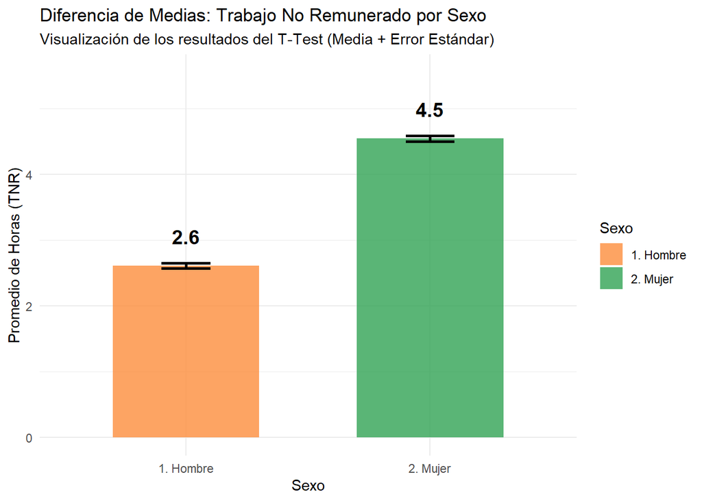

```r
#grafico primera correlacion
datos_resumen <- Base_final_final %>%
  group_by(Sexo) %>%
  summarise(
    Media_Horas = mean(tiempo_no_renumerado_horas, na.rm = TRUE),
    Error_Estandar = sd(tiempo_no_renumerado_horas, na.rm = TRUE) / sqrt(n())
  )

# gráfico
ggplot(datos_resumen, aes(x = Sexo, y = Media_Horas, fill = Sexo)) +
  # Barras que representan el promedio
  geom_col(width = 0.6, alpha = 0.8) +
  geom_errorbar(aes(ymin = Media_Horas - Error_Estandar,
                    ymax = Media_Horas + Error_Estandar),
                width = 0.2, size = 1) +

  geom_text(aes(label = round(Media_Horas, 1)),
            vjust = -1.5, size = 5, fontface = "bold") +

  scale_y_continuous(limits = c(0, max(datos_resumen$Media_Horas) + 1)) +
  scale_fill_manual(values = c("1. Hombre" = "#FD8D3C", "2. Mujer" = "#31A354")) +

  labs(title = "Diferencia de Medias: Trabajo No Remunerado por Sexo",
       subtitle = "Visualización de los resultados del T-Test (Media + Error Estándar)",
       y = "Promedio de Horas (TNR)",
       x = "Sexo") +
  theme_minimal()
```

La Figura 1 se observa la diferencia de medias encontradas en la prueba t. Los hombres registran en promedio unas 2,6 horas de trabajo no remunerado, mientras que las mujeres alcanzan cerca de 4,5 horas, reforzando la evidencia de una mayor carga de trabajo doméstico y de cuidados en las mujeres.

**2. Relación entre tiempo de trabajo no remunerado y nivel educacional** H₀: cor(tiempo_no_remunerado_horas, nivel_educacional) = 0 H₁: cor(tiempo_no_remunerado_horas, nivel_educacional) ≠ 0

```r
# TNR vs. Nivel Educacional
print("Correlación Spearman (Educación vs TNR):")
```

```
[1] "Correlación Spearman (Educación vs TNR):"
```

```r
cor.test(as.numeric(Base_final_final$Nivel_educacional),
         Base_final_final$tiempo_no_renumerado_horas,
         method = "spearman")
```

```
    Spearman's rank correlation rho

data:  as.numeric(Base_final_final$Nivel_educacional) and Base_final_final$tiempo_no_renumerado_horas
S = 164864796627, p-value = 0.00003678
alternative hypothesis: true rho is not equal to 0
sample estimates:
       rho
0.04104291
```

A partir del cálculo de la correlación de Spearman entre el nivel educacional y el tiempo de trabajo no remunerado, se observó una asociación positiva de magnitud muy pequeña (ρ = 0.041), pero estadísticamente significativa (p = 0.00003678 < 0.05). Este resultado permite rechazar la hipótesis nula de ausencia de relación con un nivel de confianza de al menos 95%. Se confirma que existe una asociación entre las variables, aunque su intensidad es débil. El coeficiente positivo (ρ = 0.041 > 0) indica que, a medida que aumenta el nivel educacional, el tiempo dedicado al trabajo no remunerado tiende a incrementarse levemente. Sin embargo, dado que la magnitud de la correlación es bastante baja, el efecto del nivel educacional sobre la carga de trabajo no remunerado es limitado en términos sustantivos. Esto sugiere que otros factores, como el género y la posición socioeconómica, probablemente tienen un peso mucho mayor en la distribución y carga de las tareas domésticas.

**figura 2**

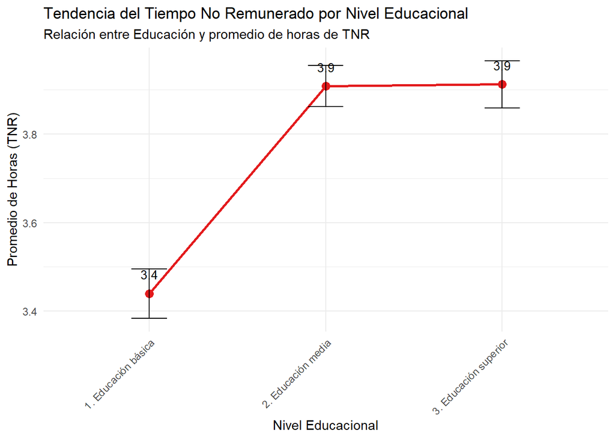

```r
#GRAFICO TNR / NIVEL EDUACIONAL

# calculo de media y error estandar
datos_resumen_educ <- Base_final_final %>%
  group_by(Nivel_educacional) %>%
  summarise(
    Media_Horas = mean(tiempo_no_renumerado_horas, na.rm = TRUE),
    Error_Estandar = sd(tiempo_no_renumerado_horas, na.rm = TRUE) / sqrt(n())
  )

# grafico de puntos y lineas
ggplot(datos_resumen_educ, aes(x = Nivel_educacional, y = Media_Horas, group = 1)) +

  geom_line(color = "#E31A1C", size = 1) +

  geom_point(size = 3, color = "#E31A1C") +

  geom_errorbar(aes(ymin = Media_Horas - Error_Estandar,
                    ymax = Media_Horas + Error_Estandar),
                width = 0.2, color = "black") +

  geom_text(aes(label = round(Media_Horas, 1)),
            vjust = -1.5, size = 3.5) +

  labs(title = "Tendencia del Tiempo No Remunerado por Nivel Educacional",
       subtitle = "Relación entre Educación y promedio de horas de TNR",
       y = "Promedio de Horas (TNR)",
       x = "Nivel Educacional") +
  theme_minimal() +
  theme(axis.text.x = element_text(angle = 45, hjust = 1))
```

**Análisis figura 2** La Figura 2 muestra la tendencia del tiempo de trabajo no remunerado según el nivel educacional. Se observa que, en promedio, quienes tienen Educación básica realizan alrededor de 3,4 horas diarias de trabajo no remunerado, mientras que este promedio aumenta aproximadamente 3,9 horas entre quienes tiene Educación media y se mantiene en un nivel muy similar en el grupo de Educación superior. La pendiente positiva de la línea indica que el tiempo de trabajo remunerado tiende a aumentar levemente a medida que sube el nivel educacional, lo que es coherente con el coeficiente de Spearman obtenido (ρ = 0,041). Sin embargo, las diferencias entre grupos son pequeñas o nulas. Fortaleciendo la idea de que otros factores parecen más determinantes en la distribución de tareas del trabajo doméstico no remunerado.

**3.Relación entre tiempo de trabajo no remunerado y quintil de ingresos** H₀: cor(tiempo_no_remunerado_horas, quintil_ingreso) = 0 H₁: cor(tiempo_no_remunerado_horas, quintil_ingreso) ≠ 0

```r
print("Correlación Spearman (Ingreso vs TNR):")
```

```
[1] "Correlación Spearman (Ingreso vs TNR):"
```

```r
cor.test(as.numeric(Base_final_final$Quintil_ingreso),
         Base_final_final$tiempo_no_renumerado_horas,
         method = "spearman")
```

```
    Spearman's rank correlation rho

data:  as.numeric(Base_final_final$Quintil_ingreso) and Base_final_final$tiempo_no_renumerado_horas
S = 179731175035, p-value = 0.000004917
alternative hypothesis: true rho is not equal to 0
sample estimates:
        rho
-0.04542927
```

A partir del cálculo de la correlación de Spearman entre el quintil de ingresos y el tiempo de trabajo no remunerado, se observó una asociación negativa de magnitud pequeña (ρ = −0.045), pero estadísticamente significativa (p = 0.0000049 < 0.05). Este resultado permite rechazar la hipótesis nula de ausencia de relación con un nivel de confianza de 95% y que confirma que existe una relación entre ambas variables, aunque con una intensidad débil. El coeficiente negativo (ρ < 0) indica que, en promedio, a medida que aumenta el quintil de ingresos, el tiempo dedicado al trabajo no remunerado tiende a disminuir levemente. Esto sugiere que, si bien los recursos económicos pueden facilitar la externalización de ciertas tareas domésticas, no se explica por sí solo las diferencias en el uso del tiempo.

**figura 3**

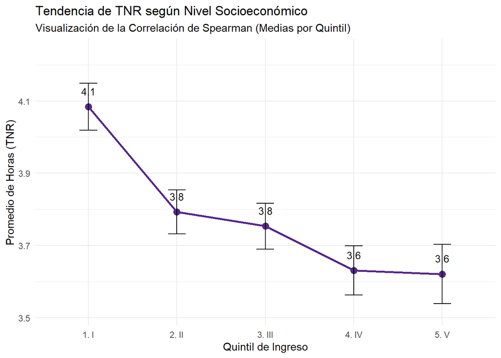

```r
#grafico corerlacion 3 tnr ingresos

datos_resumen_ingreso <- Base_final_final %>%
  group_by(Quintil_ingreso) %>%
  summarise(
    Media_Horas = mean(tiempo_no_renumerado_horas, na.rm = TRUE),
    Error_Estandar = sd(tiempo_no_renumerado_horas, na.rm = TRUE) / sqrt(n())
  )

ggplot(datos_resumen_ingreso, aes(x = Quintil_ingreso, y = Media_Horas, group = 1)) +

  # linea de tendencia
  geom_line(color = "#542788", size = 1) +

  geom_point(size = 3, color = "#542788") +
  geom_errorbar(aes(ymin = Media_Horas - Error_Estandar,
                    ymax = Media_Horas + Error_Estandar),
                width = 0.2, color = "black") +

  geom_text(aes(label = round(Media_Horas, 1)),
            vjust = -1.5, size = 3.5) +

  labs(title = "Tendencia de TNR según Nivel Socioeconómico",
       subtitle = "Visualización de la Correlación de Spearman (Medias por Quintil)",
       y = "Promedio de Horas (TNR)",
       x = "Quintil de Ingreso") +

  theme_minimal() +
  scale_y_continuous(expand = expansion(mult = c(0.1, 0.2)))
```

**4.Trabajo no remunerado / Tramos de edad** H₀: cor(Edad_tramos, tiempo_no_remunerado_horas) = 0 H₁: cor(Edad_tramos, tiempo_no_remunerados_horas) ≠ 0

```r
print("Correlación Spearman (Edad vs TNR):")
```

```
[1] "Correlación Spearman (Edad vs TNR):"
```

```r
cor.test(as.numeric(Base_final_final$Edad_tramos),
         Base_final_final$tiempo_no_renumerado_horas,
         method = "spearman")
```

```
    Spearman's rank correlation rho

data:  as.numeric(Base_final_final$Edad_tramos) and Base_final_final$tiempo_no_renumerado_horas
S = 174824262576, p-value = 0.08962
alternative hypothesis: true rho is not equal to 0
sample estimates:
        rho
-0.01688759
```

A partir del cálculo de la correlación de Spearman entre Trabajo no remunerado y Tramos de edad, se observó una asociación negativa de magnitud insignificante (ρ = -0.017), que no es estadísticamente significativa (p = 0.090). Este resultado no permite rechazar la hipótesis nula de no asociación con un nivel de confianza del 95%, por lo que no se confirma la existencia de una relación significativa entre estas variables.

**Figura 4**

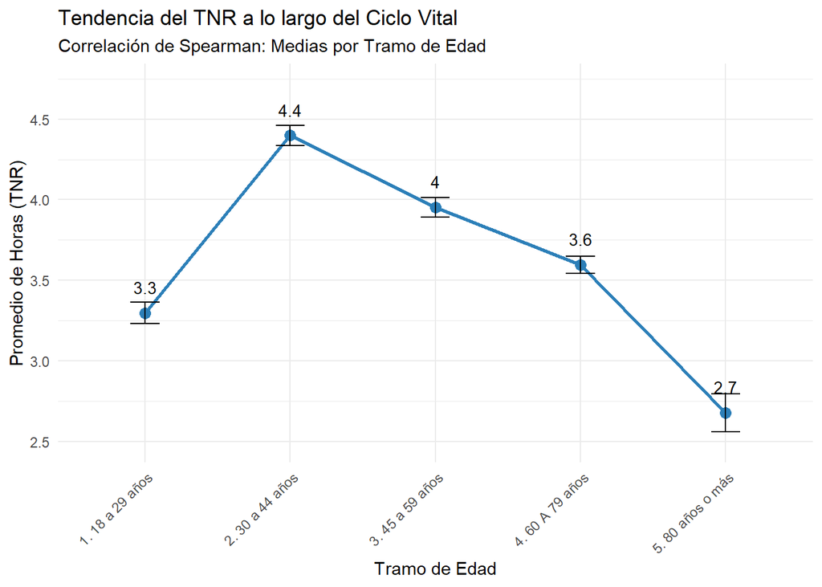

```r
#grafico tnr tramos de ead

# resumen de datos con media y error estandar
datos_resumen_edad <- Base_final_final %>%
  group_by(Edad_tramos) %>%
  summarise(
    Media_Horas = mean(tiempo_no_renumerado_horas, na.rm = TRUE),
    Error_Estandar = sd(tiempo_no_renumerado_horas, na.rm = TRUE) / sqrt(n())
  )

# Grafico
ggplot(datos_resumen_edad, aes(x = Edad_tramos, y = Media_Horas, group = 1)) +

  geom_line(color = "#2C7FB8", size = 1) +

  geom_point(size = 3, color = "#2C7FB8") +

  geom_errorbar(aes(ymin = Media_Horas - Error_Estandar,
                    ymax = Media_Horas + Error_Estandar),
                width = 0.2, color = "black") +

  geom_text(aes(label = round(Media_Horas, 1)),
            vjust = -1.5, size = 3.5) +

  labs(title = "Tendencia del TNR a lo largo del Ciclo Vital",
       subtitle = "Correlación de Spearman: Medias por Tramo de Edad",
       y = "Promedio de Horas (TNR)",
       x = "Tramo de Edad") +

  theme_minimal() +

  theme(axis.text.x = element_text(angle = 45, hjust = 1)) +

  scale_y_continuous(expand = expansion(mult = c(0.1, 0.2)))
```

**5. Asociación entre sexo y quintil de ingresos** H₀: V_cramer(sexo, quintil_ingreso) = 0 H₁: V_cramer(sexo, quintil_ingreso) ≠ 0

```r
Tabla_Cruzada <- Base_final_final %>%
  count(Quintil_ingreso, Sexo) %>%
  group_by(Sexo) %>%
  mutate(Porcentaje = round(n / sum(n) * 100, 1)) %>%
  pivot_wider(names_from = Sexo, values_from = c(n, Porcentaje), names_glue = "{Sexo}_{.value}") %>%
  select(Quintil_ingreso, `1. Hombre_n`, `1. Hombre_Porcentaje`, `2. Mujer_n`, `2. Mujer_Porcentaje`) %>%
  rename(
    "Quintil" = Quintil_ingreso,
    "Hombres (N)" = `1. Hombre_n`, "Hombres (%)" = `1. Hombre_Porcentaje`,
    "Mujeres (N)" = `2. Mujer_n`, "Mujeres (%)" = `2. Mujer_Porcentaje`
  )

# Mostrar Tabla
kable(Tabla_Cruzada, caption = "Tabla 2. Distribución de Ingresos por Sexo")
```

Tabla 2. Distribución de Ingresos por Sexo

| Quintil | Hombres (N) | Hombres (%) | Mujeres (N) | Mujeres (%) |
| --- | --- | --- | --- | --- |
| 1. I | 786 | 20.3 | 1621 | 26.0 |
| 2. II | 838 | 21.7 | 1601 | 25.7 |
| 3. III | 829 | 21.4 | 1415 | 22.7 |
| 4. IV | 793 | 20.5 | 1000 | 16.0 |
| 5. V | 622 | 16.1 | 599 | 9.6 |

**Chi-Cuadrado tabla cruzada**

```r
#asociación chi cuadrado para ver si hay correlación

# Tabla de contingencia cruda para el calculo ya que con la anterior dio errores

tabla_base <- table(Base_final_final$Quintil_ingreso, Base_final_final$Sexo)

# Chicuadrado
test_chi <- chisq.test(tabla_base)

# resultados de la prueba
print("--- Resultado Chi-Cuadrado ---")
```

```
[1] "--- Resultado Chi-Cuadrado ---"
```

```r
print(test_chi)
```

```
    Pearson's Chi-squared test

data:  tabla_base
X-squared = 159.51, df = 4, p-value < 0.00000000000000022
```

El test chi-cuadrado arroja un valor de X² = 159.51, con 4 grados de libertad y un p-value < 0.00000000000000022, lo que indica una asociación estadísticamente significativa entre las variables de la tabla cruzada. Dado que el p-value es extremadamente bajo, se rechaza la hipótesis de independencia y se concluye que las categorías de ambas variables no se distribuyen de manera aleatoria, existiendo una relación entre ellas. Pese a que la prueba solo detecta la existencia de la asociación y no su dirección, el tamaño del estadístico X² sugiere que las diferencias observadas entre las categorías son notorias, es decir, algunas combinaciones de categorías ocurren mucho más o menos de lo esperado si las variables fueran independientes. En términos sustantivos, el resultado implica que las diferencias entre los grupos comparados no pueden explicarse por azar, por lo que es necesario examinar la tabla para identificar qué categorías contribuyen más al efecto. Esto refuerza la importancia de seguir analizando cómo se distribuyen las personas entre los distintos niveles de ambas variables.

**V de Cramer**

```r
#  calculamos V de Cramer
v_cramer <- sqrt(test_chi$statistic / sum(tabla_base))

print(paste("V de Cramer:", round(v_cramer, 3)))
```

```
[1] "V de Cramer: 0.126"
```

El coeficiente de V de Cramer obtenido es V = 0.126. Dado que este indicador toma valores entre 0 y 1 indicando una relación débil entre sexo y quintil de ingreso. Esto significa que, aunque Chi-cuadrado mostró que las diferencias en la distribución de los quintiles de ingresos según sexo no son productos del azar (asociación estadísticamente significativa), la intensidad del vínculo de este es baja. Es decir, el sexo se relaciona con el nivel de ingreso, pero solo explica una pequeña parte de las diferencias observadas, debido a que hay otros factores estructurales (educación, inserción laboral, ocupación) que probablemente tienen un aporte significativo a la desigualdad de ingresos

**Gráfico de distribución de quintiles de ingreso según sexo**

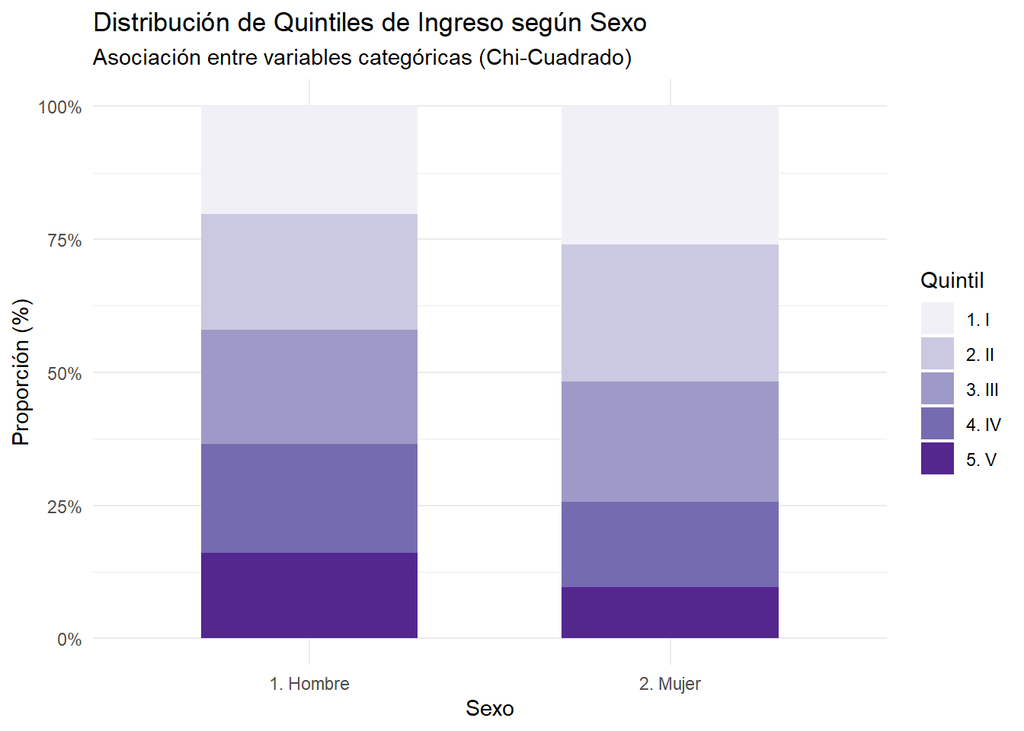

```r
#grafico

ggplot(Base_final_final, aes(x = Sexo, fill = Quintil_ingreso)) +

  geom_bar(position = "fill", width = 0.6) +

  labs(title = "Distribución de Quintiles de Ingreso según Sexo",
       subtitle = "Asociación entre variables categóricas (Chi-Cuadrado)",
       y = "Proporción (%)",
       x = "Sexo",
       fill = "Quintil") +

  scale_y_continuous(labels = scales::percent) +

  theme_minimal() +
  scale_fill_brewer(palette = "Purples")
```

El gráfico muestra que la distribución de los quintiles de ingreso varía según el sexo. Aunque las diferencias no son muy marcadas, se observa que los hombres tienen una presencia ligeramente mayor en los quintiles altos, mientras que las mujeres se concentran un poco más en los quintiles bajos. Esto refleja una desigualdad moderada en la estructura de ingresos entre hombres y mujeres, coherente con la asociación significativa encontrada en la prueba Chi-cuadrado.

**Conclusiones**

El presente estudio analizó la relación entre el tiempo dedicado al trabajo no remunerado (TNR) y diversos factores sociodemográficos, incluyendo sexo, nivel educacional, quintil de ingresos y edad. En conjunto, los resultados mostraron variables significativamente asociadas con el TNR, aunque la magnitud de dichas relaciones tienden a ser moderada o baja, evidenciando patrones consistentes pero no extremos de desigualdad en la distribución del trabajo doméstico. El hallazgo más relevante corresponde a la marcada brecha de género: las mujeres dedican, en promedio, casi dos horas más de TNR que los hombres, lo que confirma la persistencia de una división sexual del trabajo que carga desproporcionadamente a las mujeres con labores domésticas y de cuidado. Alineándose a estudios previos que documentan feminización del TNR y distribución desigual del tiempo en los hogares. Asimismo, el ingreso mostró una relación negativa con el TNR: los quintiles más bajos dedican más tiempo a estas tareas, aunque la diferencia entre extremos es moderada. Esta tendencia sugiere que los recursos económicos influyen en la posibilidad de externalizar o redistribuir responsabilidades domésticas. Por su parte, el nivel educacional presentó una asociación significativa pero de magnitud muy baja, indicando que las brechas educativas no modifican sustantivamente la carga de trabajo no remunerado. En contraste, la edad no mostró una relación significativa con el TNR, lo que sugiere que las cargas de cuidado no siguen un patrón lineal a lo largo del ciclo vital, sino que responden a dinámicas familiares más específicas. Respecto a la relación entre sexo e ingreso, el análisis mostró una asociación significativa pero débil, reflejando que, aunque el género influye en la posición económica, esta desigualdad está mediada por otros factores estructurales como ocupación, educación y condiciones laborales. Finalmente, aunque los efectos observados son en su mayoría bajos, el estudio confirma la importancia de seguir analizando el TNR como un componente central de las desigualdades de género y clase. Futuros estudios podrían profundizar incorporando más variables y enfoques que permitan comprender mejor estas dinámicas.

**Bibliografía**

Barriga, F., Durán, G., Sáez, B., & Sato, A. (2020). No es amor, es trabajo no pagado: Un análisis del trabajo de las mujeres en el Chile actual. Estudios de la Fundación SOL. https://fundacionsol.cl/cl_luzit_herramientas/static/wp-content/uploads/2020/03/No-es-amor-es-trabajo-no-pagado-2020.pdf

Comisión Económica para América Latina y el Caribe (CEPAL). (s.f.). Tiempo dedicado al trabajo doméstico y de cuidado no remunerado [Indicador]. Observatorio de Igualdad de Género de América Latina y el Caribe. https://oig.cepal.org/es/indicadores?id=2287

Grupo de Trabajo para la elaboración de una guía metodológica sobre mediciones de uso del tiempo en América Latina y el Caribe. (2022). Guía metodológica sobre las mediciones de uso del tiempo en América Latina y el Caribe (LC/CEA.11/17). Santiago: Comisión Económica para América Latina y el Caribe (CEPAL). https://repositorio.cepal.org/server/api/core/bitstreams/f69e5027-c677-42ab-87cc-1efff01f5b53/content

OECD. (2025). Gender gaps in paid and unpaid work persist. OECD Publishing. https://www.oecd.org/en/publications/gender-gaps-in-paid-and-unpaid-work-persist_25a6c5dc-en.html

Vega Montiel, A. (2007). Por la visibilidad de las amas de casa: rompiendo la invisibilidad del trabajo doméstico. Política y Cultura, (28), 173‑193. http://www.scielo.org.mx/scielo.php?script=sci_arttext&pid=S018877422007000200008&lng=es&tlng=es

Waring, M. (1990). Si las mujeres contaran: Una nueva economía feminista (ed. en rústica). Harper Collins Publishers. https://www.roiw.org/1992/237.pdf?utm_source